# V3

## Version 3 Classification Steps

In version 3 of the classification process, the same steps were followed as in version 2 with one additional step:

1. **Model Training:** An extra model, MobileNetV2, was included in the training process along with the updated custom model architecture, VGG16, and resnet50.
2. **Fine Tuning:** Fine tune the models by train some final layers from the main arch not only the top layers.

The remaining steps were the same as in version 2:

1. **Import Libraries:** The necessary libraries were imported to facilitate the implementation of the classification process.
2. **Exploratory Data Analysis:** An exploratory data analysis was conducted on both fake and original images to gain insight into the dataset's characteristics.
3. **Data Preparation:** The train, validation, and test datasets were prepared for training by resizing the images to 128x128x3.
4. **Model Training:** The data was trained using four different models - the updated custom model architecture, VGG16, resnet50, and MobileNetV2 - to identify the most appropriate model for the classification task.

# 1. Imports

```python
import os
import numpy as np
import cv2
from PIL import Image
import seaborn as sns
import matplotlib.pyplot as plt
%matplotlib inline

import tensorflow as tf
from sklearn.model_selection import train_test_split
from tensorflow.keras.preprocessing.image import ImageDataGenerator, img_to_array, load_img
from tensorflow.keras import layers, models
from tensorflow.keras.models import Sequential , Model, load_model
from tensorflow.keras.layers import Activation, Dropout, Flatten, Dense, Conv2D, MaxPooling2D
from tensorflow.keras.utils import to_categorical
from keras.callbacks import EarlyStopping
from tensorflow.keras.applications.resnet import ResNet50
from tensorflow.keras.applications.vgg16 import VGG16
from tensorflow.keras.applications.vgg16 import preprocess_input
from tensorflow.keras.applications.mobilenet_v2 import MobileNetV2
from keras import optimizers
from tensorflow.keras.optimizers import Adam

from sklearn.metrics import log_loss, accuracy_score, confusion_matrix, classification_report

from warnings import filterwarnings
filterwarnings("ignore")
```

```python
# Check running on GPU

len(tf.config.experimental.list_physical_devices("GPU"))
```

```
1
```

# 2. Exploratory Data Analysis

## 2.1. Number of Images

```python
fake_path = 'data/fake/images/'
original_path = 'data/original/'
```

```python
print('Number of fake images = {}'.format((len(os.listdir(fake_path))))) # the folder contains both fake image and its mask
print('Number of pristine images = {}'.format((len(os.listdir(original_path)))))
```

```
Number of fake images = 18194
Number of pristine images = 31783
```

## 2.2. Fake Images Shape

```python
fakes = os.listdir(fake_path)
```

```python
fake_shapes=[]

for fake in fakes:
    img = Image.open(fake_path+fake)
    img_array = np.array(img)
    fake_shapes.append(img_array.shape)
```

```python
# random 20 sample of fake images shape

for i in range(20):
    ind=np.random.randint(0, len(fake_shapes))
    print(str(ind) +'\t\t'+ str(fake_shapes[ind]) +'\t\t'+fakes[ind])
```

```
15316		(640, 480, 3)		4_000000413970.jpg
15832		(426, 640, 3)		5_000000135336.jpg
6674		(480, 640, 3)		11_000000492627.jpg
12259		(427, 640, 3)		2_000000383893.jpg
1679		(425, 640, 3)		0_000000152019.jpg
9784		(426, 640, 3)		1_000000413719.jpg
5459		(480, 640, 3)		0_000000506401.jpg
17538		(425, 640, 3)		8_000000040911.jpg
4523		(427, 640, 3)		0_000000418115.jpg
15975		(512, 640, 3)		5_000000236272.jpg
17879		(480, 640, 3)		8_000000565312.jpg
9441		(640, 480, 3)		1_000000354603.jpg
16266		(427, 640, 3)		5_000000458448.jpg
8118		(640, 396, 3)		1_000000119505.jpg
9408		(375, 500, 3)		1_000000348221.jpg
5541		(500, 320, 3)		0_000000514541.jpg
1527		(347, 640, 3)		0_000000140473.jpg
6052		(333, 500, 3)		0_000000562801.jpg
2175		(640, 426, 3)		0_000000200500.jpg
7885		(640, 638, 3)		1_000000076742.jpg
```

```python
heights=[]
widths=[]

for fake in fake_shapes:
    heights.append(fake[0])
    widths.append(fake[1])

print('minimum height = {}'.format(min(heights)))
print('maximum height = {}'.format(max(heights)))

print('minimum width = {}'.format(min(widths)))
print('maximum width = {}'.format(max(widths)))
```

```
minimum height = 135
maximum height = 640
minimum width = 125
maximum width = 640
```

## 2.3. Original Images Shape

```python
originals = os.listdir(original_path)
```

```python
original_shapes=[]

for original in originals:
    img = Image.open(original_path+original)
    img_array = np.array(img)
    original_shapes.append(img_array.shape)
```

```python
# random 20 sample of original images shape

for i in range(20):
    ind=np.random.randint(0, len(original_shapes))
    print(str(ind) +'\t\t'+ str(original_shapes[ind]) +'\t\t'+originals[ind])
```

```
18752		(500, 375, 3)		419420971.jpg
4129		(375, 500, 3)		2215875786.jpg
18247		(500, 400, 3)		4063231596.jpg
75		(500, 332, 3)		1021293940.jpg
28880		(500, 375, 3)		6586954247.jpg
22823		(500, 332, 3)		4734385519.jpg
25081		(500, 326, 3)		4920323820.jpg
28824		(375, 500, 3)		6533409787.jpg
14234		(333, 500, 3)		3445428367.jpg
20697		(389, 500, 3)		4545104306.jpg
26376		(355, 500, 3)		518602687.jpg
4803		(333, 500, 3)		2304938797.jpg
3160		(333, 500, 3)		2064841667.jpg
29991		(334, 500, 3)		7247604030.jpg
23454		(375, 500, 3)		4788006130.jpg
29315		(333, 500, 3)		6887324285.jpg
22823		(500, 332, 3)		4734385519.jpg
9760		(333, 500, 3)		2923475135.jpg
5047		(333, 500, 3)		2335428699.jpg
31204		(333, 500, 3)		8174939463.jpg
```

```python
heights=[]
widths=[]

for original in original_shapes:
    heights.append(original[0])
    widths.append(original[1])

print('minimum height = {}'.format(min(heights)))
print('maximum height = {}'.format(max(heights)))

print('minimum width = {}'.format(min(widths)))
print('maximum width = {}'.format(max(widths)))
```

```
minimum height = 112
maximum height = 500
minimum width = 164
maximum width = 500
```

After all data cleaning we have :

- 31783 original images (3 channels)
- 18194 fake images (3 channels)

# 3. Dataset Preparation

## 3.1. Concatenate Original And Fake Images

```python
len(originals)
```

```
31783
```

```python
len(fakes)
```

```
18194
```

```python
image_names=[]

for i in range(0, len(originals)):
    image_names.append(originals[i])
for i in range(0, len(fakes)):
    image_names.append(fakes[i])
```

```python
len(image_names)
```

```
49977
```

## 3.2. Train Test Split

```python
labels=[0]*31783+[1]*18194
```

```python
x_train, x, y_train, y = train_test_split(image_names, labels, test_size=0.2, stratify=labels)
```

```python
x_test, x_valid, y_test, y_valid = train_test_split(x, y, test_size=0.5, stratify=y)
```

```python
print("X train: ", len(x_train) ,", Y train: ", len(y_train))
print("X validation: ",len(x_valid) ,", Y validation: ", len(y_valid))
print("X test: ",len(x_test) ,", Y test: ", len(y_test))
```

```
X train:  39981 , Y train:  39981
X validation:  4998 , Y validation:  4998
X test:  4998 , Y test:  4998
```

## 3.3. Prepare Train Set

```python
# read train images and resize it to be (128,128) so we can train the model on it

dim=(128,128)

x_train_images=[]

for ind, x in enumerate(x_train):
    if y_train[ind]==0:
        img = Image.open(original_path+x)
        img_array = np.array(img)
    if y_train[ind]==1:
        img = Image.open(fake_path+x)
        img_array = np.array(img)
    img = cv2.resize(img_array, dim, interpolation = cv2.INTER_AREA)

    x_train_images.append(img)
```

```python
heights=[]
widths=[]

for image in x_train_images:
    heights.append(image.shape[0])
    widths.append(image.shape[1])

print('minimum height = {}'.format(min(heights)))
print('maximum height = {}'.format(max(heights)))

print('minimum width = {}'.format(min(widths)))
print('maximum width = {}'.format(max(widths)))
```

```
minimum height = 128
maximum height = 128
minimum width = 128
maximum width = 128
```

```python
x_train_fake_ind=[]

for ind, x in enumerate(x_train):
    if y_train[ind]==1:
        x_train_fake_ind.append(ind)
```

```python
x_train_original_ind=[]

for ind, x in enumerate(x_train):
    if y_train[ind]==0:
        x_train_original_ind.append(ind)
```

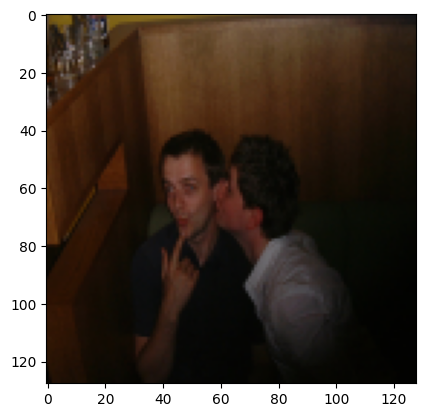

```python
plt.imshow(x_train_images[x_train_original_ind[0]][:,:,:])
```

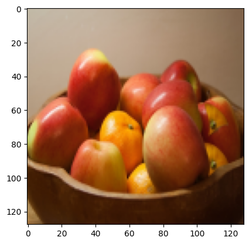

```python
plt.imshow(x_train_images[x_train_fake_ind[1]][:,:,:])
```

## 3.4. Prepare Valid Set

```python
x_valid_images=[]

for ind, x in enumerate(x_valid):
    if y_valid[ind]==0:
        img = Image.open(original_path+x)
        img_array = np.array(img)
    if y_valid[ind]==1:
        img = Image.open(fake_path+x)
        img_array = np.array(img)
    img = cv2.resize(img_array, dim, interpolation = cv2.INTER_AREA)

    x_valid_images.append(img)
```

## 3.5. Prepare Test Set

```python
x_test_images=[]

for ind, x in enumerate(x_test):
    if y_test[ind]==0:
        img = Image.open(original_path+x)
        img_array = np.array(img)
    if y_test[ind]==1:
        img = Image.open(fake_path+x)
        img_array = np.array(img)
    img = cv2.resize(img_array, dim, interpolation = cv2.INTER_AREA)

    x_test_images.append(img)
```

# 4. Image Data Generator

```python
# convert the list of images to array of 4 dimensions

x_train_images = np.stack(x_train_images)
x_valid_images = np.stack(x_valid_images)
x_test_images = np.stack(x_test_images)
```

```python
print( "\nx_train_images shape is: " , x_train_images.shape)
print( "\nx_valid_images shape is: " , x_valid_images.shape)
print( "\nx_test_images shape is: " , x_test_images.shape)
```

```
x_train_images shape is:  (39981, 128, 128, 3)

x_valid_images shape is:  (4998, 128, 128, 3)

x_test_images shape is:  (4998, 128, 128, 3)
```

```python
# Create an instance of ImageDataGenerator for data augmentation and preprocessing

train_datagen = ImageDataGenerator(
    rescale=1./255,
    rotation_range=10,
    width_shift_range=0.1,
    height_shift_range=0.1,
    shear_range=0.1,
    zoom_range=0.1,
    horizontal_flip=True,
    vertical_flip=False,
    fill_mode='reflect'
)

# Define the batch size

batch_size = 32

# Define the generator for the training data

train_generator = train_datagen.flow(
    x_train_images,
    y_train,
    batch_size=batch_size,
    seed=42,
    shuffle=True,
)

# Define the generator for the validation data

valid_datagen = ImageDataGenerator(rescale=1./255)

valid_generator = valid_datagen.flow(
    x_valid_images,
    y_valid,
    batch_size=batch_size,
    seed=42,
    shuffle=True,
)
```

```python
len(train_generator)
```

```
1250
```

```python
train_generator[0][0][0].shape
```

```
(128, 128, 3)
```

```python
len(valid_generator)
```

```
157
```

```python
valid_generator
```

```
<keras.preprocessing.image.NumpyArrayIterator at 0x1ec49983f70>
```

# 5. Training Deep Learning Models

## 5.1. Custom Model

```python
image_shape=(128,128,3)
custom_model = Sequential()

custom_model.add(Conv2D(32, (3, 3), activation='relu', input_shape=image_shape))
custom_model.add(MaxPooling2D(pool_size=(2, 2)))
custom_model.add(Conv2D(64, (3, 3), activation='relu'))
custom_model.add(MaxPooling2D(pool_size=(2, 2)))

custom_model.add(Conv2D(128, (3, 3), activation='relu'))
custom_model.add(MaxPooling2D(pool_size=(2, 2)))

custom_model.add(Conv2D(128, (3, 3), activation='relu'))
custom_model.add(MaxPooling2D(pool_size=(2, 2)))

custom_model.add(Flatten())

custom_model.add(Dense(512, activation='relu'))
custom_model.add(Dropout(0.5))

custom_model.add(Dropout(0.3))

custom_model.add(Dense(1, activation='sigmoid'))

custom_model.compile(loss='binary_crossentropy',
                     optimizer='adam',
                     metrics=['accuracy'])
```

```python
custom_model.summary()
```

```
Model: "sequential"
_________________________________________________________________
Layer (type)                 Output Shape              Param #
=================================================================
conv2d (Conv2D)              (None, 126, 126, 32)      896
_________________________________________________________________
max_pooling2d (MaxPooling2D) (None, 63, 63, 32)        0
_________________________________________________________________
conv2d_1 (Conv2D)            (None, 61, 61, 64)        18496
_________________________________________________________________
max_pooling2d_1 (MaxPooling2 (None, 30, 30, 64)        0
_________________________________________________________________
conv2d_2 (Conv2D)            (None, 28, 28, 128)       73856
_________________________________________________________________
max_pooling2d_2 (MaxPooling2 (None, 14, 14, 128)       0
_________________________________________________________________
conv2d_3 (Conv2D)            (None, 12, 12, 128)       147584
_________________________________________________________________
max_pooling2d_3 (MaxPooling2 (None, 6, 6, 128)         0
_________________________________________________________________
flatten (Flatten)            (None, 4608)              0
_________________________________________________________________
dense (Dense)                (None, 512)               2359808
_________________________________________________________________
dropout (Dropout)            (None, 512)               0
_________________________________________________________________
dropout_1 (Dropout)          (None, 512)               0
_________________________________________________________________
dense_1 (Dense)              (None, 1)                 513
=================================================================
Total params: 2,601,153
Trainable params: 2,601,153
Non-trainable params: 0
_________________________________________________________________
```

```python
# CallBack function to stop the training
# if 10 epochs pass without increase val_acc

earlystop = EarlyStopping(monitor='val_accuracy', patience=10, mode='max')
```

```python
custom_model_history = custom_model.fit_generator(train_generator,
                                     validation_data  = valid_generator,
                                     epochs = 100,
                                     steps_per_epoch=(len(train_generator)) ,
                                     validation_steps=(len(valid_generator)),
                                     callbacks=[earlystop])
```

## 5.2. Custome Model Evaluation

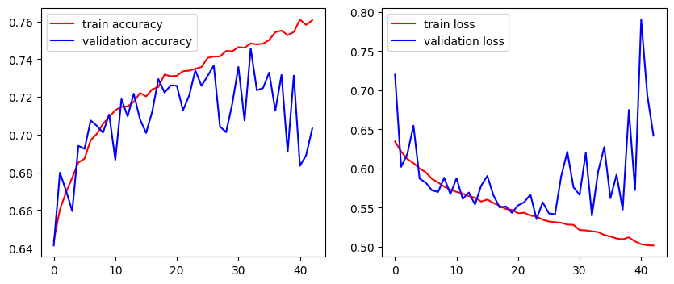

```python
plt.figure(figsize = (10,4))
plt.subplot(1,2,1)
plt.plot(custom_model_history.history["accuracy"], label = "train accuracy", color = "red")
plt.plot(custom_model_history.history["val_accuracy"], label = "validation accuracy", color = "blue")
plt.legend()

plt.subplot(1,2,2)
plt.plot(custom_model_history.history["loss"], label = "train loss", color = "red")
plt.plot(custom_model_history.history["val_loss"], label = "validation loss", color = "blue")

plt.legend()
plt.show()
```

```python
custom_model_predictions = custom_model.predict(x_test_images, verbose = 1,workers=-1)
```

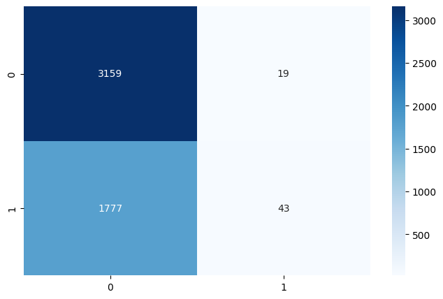

```python
plt.figure(figsize = (8,5))
sns.heatmap(confusion_matrix(y_test, custom_model_predictions.round()), annot = True,fmt="d",cmap = "Blues")
plt.show()
```

```python
print(classification_report(y_test,custom_model_predictions.round()))
```

```
              precision    recall  f1-score   support

           0       0.64      0.99      0.78      3178
           1       0.69      0.02      0.05      1820

    accuracy                           0.64      4998
   macro avg       0.67      0.51      0.41      4998
weighted avg       0.66      0.64      0.51      4998
```

```python
custom_model.save('custom_model_V2.h5')
```

## 5.3. VGG16 Model

```python
## Loading VGG16 model
base_model = VGG16(weights="imagenet", include_top=False, input_shape=image_shape)
base_model.trainable = False ## Not trainable weights

base_model.summary()
```

```
Model: "vgg16"
_________________________________________________________________
Layer (type)                 Output Shape              Param #
=================================================================
input_1 (InputLayer)         [(None, 128, 128, 3)]     0
_________________________________________________________________
block1_conv1 (Conv2D)        (None, 128, 128, 64)      1792
_________________________________________________________________
block1_conv2 (Conv2D)        (None, 128, 128, 64)      36928
_________________________________________________________________
block1_pool (MaxPooling2D)   (None, 64, 64, 64)        0
_________________________________________________________________
block2_conv1 (Conv2D)        (None, 64, 64, 128)       73856
_________________________________________________________________
block2_conv2 (Conv2D)        (None, 64, 64, 128)       147584
_________________________________________________________________
block2_pool (MaxPooling2D)   (None, 32, 32, 128)       0
_________________________________________________________________
block3_conv1 (Conv2D)        (None, 32, 32, 256)       295168
_________________________________________________________________
block3_conv2 (Conv2D)        (None, 32, 32, 256)       590080
_________________________________________________________________
block3_conv3 (Conv2D)        (None, 32, 32, 256)       590080
_________________________________________________________________
block3_pool (MaxPooling2D)   (None, 16, 16, 256)       0
_________________________________________________________________
block4_conv1 (Conv2D)        (None, 16, 16, 512)       1180160
_________________________________________________________________
block4_conv2 (Conv2D)        (None, 16, 16, 512)       2359808
_________________________________________________________________
block4_conv3 (Conv2D)        (None, 16, 16, 512)       2359808
_________________________________________________________________
block4_pool (MaxPooling2D)   (None, 8, 8, 512)         0
_________________________________________________________________
block5_conv1 (Conv2D)        (None, 8, 8, 512)         2359808
_________________________________________________________________
block5_conv2 (Conv2D)        (None, 8, 8, 512)         2359808
_________________________________________________________________
block5_conv3 (Conv2D)        (None, 8, 8, 512)         2359808
_________________________________________________________________
block5_pool (MaxPooling2D)   (None, 4, 4, 512)         0
=================================================================
Total params: 14,714,688
Trainable params: 0
Non-trainable params: 14,714,688
_________________________________________________________________
```

```python
flatten_layer = layers.Flatten()
dense_layer_1 = layers.Dense(50, activation='relu')
dense_layer_2 = layers.Dense(20, activation='relu')
prediction_layer = layers.Dense(1, activation='sigmoid')

vgg_model = models.Sequential([
    base_model,
    flatten_layer,
    dense_layer_1,
    dense_layer_2,
    prediction_layer
])

vgg_model.compile(loss='binary_crossentropy',
              optimizer='adam',
              metrics=['accuracy'])

vgg_model.summary()
```

```
Model: "sequential_1"
_________________________________________________________________
Layer (type)                 Output Shape              Param #
=================================================================
vgg16 (Functional)           (None, 4, 4, 512)         14714688
_________________________________________________________________
flatten_1 (Flatten)          (None, 8192)              0
_________________________________________________________________
dense_2 (Dense)              (None, 50)                409650
_________________________________________________________________
dense_3 (Dense)              (None, 20)                1020
_________________________________________________________________
dense_4 (Dense)              (None, 1)                 21
=================================================================
Total params: 15,125,379
Trainable params: 410,691
Non-trainable params: 14,714,688
_________________________________________________________________
```

```python
vgg_model_history = vgg_model.fit_generator(train_generator,
                                  validation_data  = valid_generator,
                                  epochs = 100,
                                  steps_per_epoch=(len(train_generator)) ,
                                  validation_steps=(len(valid_generator)),
                                  callbacks=[earlystop]
                             )
```

## 5.4. VGG16 Model Evaluation

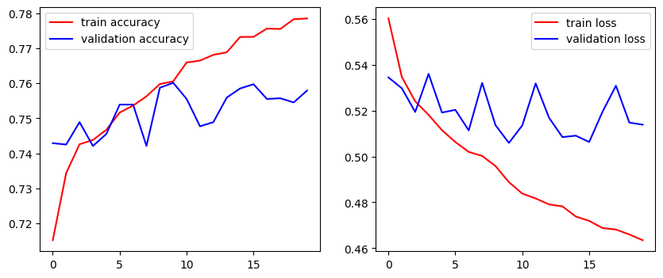

```python
plt.figure(figsize = (10,4))
plt.subplot(1,2,1)
plt.plot(vgg_model_history.history["accuracy"], label = "train accuracy", color = "red")
plt.plot(vgg_model_history.history["val_accuracy"], label = "validation accuracy", color = "blue")
plt.legend()

plt.subplot(1,2,2)
plt.plot(vgg_model_history.history["loss"], label = "train loss", color = "red")
plt.plot(vgg_model_history.history["val_loss"], label = "validation loss", color = "blue")

plt.legend()
plt.show()
```

```python
vgg_model_predictions = vgg_model.predict(x_test_images, verbose = 1,workers=-1)
```

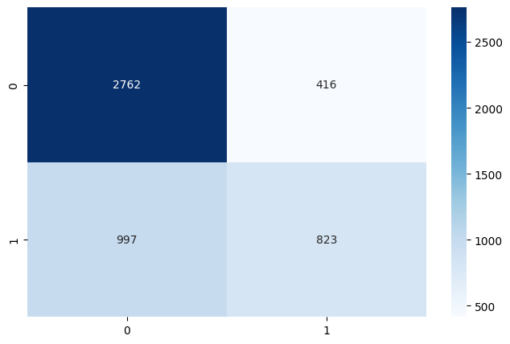

```python
plt.figure(figsize = (8,5))
sns.heatmap(confusion_matrix(y_test, vgg_model_predictions.round()), annot = True,fmt="d",cmap = "Blues")
plt.show()
```

```python
print(classification_report(y_test,vgg_model_predictions.round()))
```

```
              precision    recall  f1-score   support

           0       0.73      0.87      0.80      3178
           1       0.66      0.45      0.54      1820

    accuracy                           0.72      4998
   macro avg       0.70      0.66      0.67      4998
weighted avg       0.71      0.72      0.70      4998
```

## 5.5. RasNet50 Model

```python
# load RaseNet50
base_model=ResNet50(weights='imagenet', include_top=False, input_shape=(128, 128, 3))
base_model.trainable = False

base_model.summary()
```

```
Model: "resnet50"
__________________________________________________________________________________________________
Layer (type)                    Output Shape         Param #     Connected to
==================================================================================================
input_2 (InputLayer)            [(None, 128, 128, 3) 0
__________________________________________________________________________________________________
conv1_pad (ZeroPadding2D)       (None, 134, 134, 3)  0           input_2[0][0]
__________________________________________________________________________________________________
conv1_conv (Conv2D)             (None, 64, 64, 64)   9472        conv1_pad[0][0]
__________________________________________________________________________________________________
conv1_bn (BatchNormalization)   (None, 64, 64, 64)   256         conv1_conv[0][0]
__________________________________________________________________________________________________
conv1_relu (Activation)         (None, 64, 64, 64)   0           conv1_bn[0][0]
__________________________________________________________________________________________________
pool1_pad (ZeroPadding2D)       (None, 66, 66, 64)   0           conv1_relu[0][0]
__________________________________________________________________________________________________
pool1_pool (MaxPooling2D)       (None, 32, 32, 64)   0           pool1_pad[0][0]
__________________________________________________________________________________________________
conv2_block1_1_conv (Conv2D)    (None, 32, 32, 64)   4160        pool1_pool[0][0]
__________________________________________________________________________________________________
conv2_block1_1_bn (BatchNormali (None, 32, 32, 64)   256         conv2_block1_1_conv[0][0]
__________________________________________________________________________________________________
conv2_block1_1_relu (Activation (None, 32, 32, 64)   0           conv2_block1_1_bn[0][0]
__________________________________________________________________________________________________
conv2_block1_2_conv (Conv2D)    (None, 32, 32, 64)   36928       conv2_block1_1_relu[0][0]
__________________________________________________________________________________________________
conv2_block1_2_bn (BatchNormali (None, 32, 32, 64)   256         conv2_block1_2_conv[0][0]
__________________________________________________________________________________________________
conv2_block1_2_relu (Activation (None, 32, 32, 64)   0           conv2_block1_2_bn[0][0]
__________________________________________________________________________________________________
conv2_block1_0_conv (Conv2D)    (None, 32, 32, 256)  16640       pool1_pool[0][0]
__________________________________________________________________________________________________
conv2_block1_3_conv (Conv2D)    (None, 32, 32, 256)  16640       conv2_block1_2_relu[0][0]
__________________________________________________________________________________________________
conv2_block1_0_bn (BatchNormali (None, 32, 32, 256)  1024        conv2_block1_0_conv[0][0]
__________________________________________________________________________________________________
conv2_block1_3_bn (BatchNormali (None, 32, 32, 256)  1024        conv2_block1_3_conv[0][0]
__________________________________________________________________________________________________
conv2_block1_add (Add)          (None, 32, 32, 256)  0           conv2_block1_0_bn[0][0]
                                                                 conv2_block1_3_bn[0][0]
```

[output cut: 319 more lines]

```
conv5_block3_2_relu (Activation (None, 4, 4, 512)    0           conv5_block3_2_bn[0][0]
__________________________________________________________________________________________________
conv5_block3_3_conv (Conv2D)    (None, 4, 4, 2048)   1050624     conv5_block3_2_relu[0][0]
__________________________________________________________________________________________________
conv5_block3_3_bn (BatchNormali (None, 4, 4, 2048)   8192        conv5_block3_3_conv[0][0]
__________________________________________________________________________________________________
conv5_block3_add (Add)          (None, 4, 4, 2048)   0           conv5_block2_out[0][0]
                                                                 conv5_block3_3_bn[0][0]
__________________________________________________________________________________________________
conv5_block3_out (Activation)   (None, 4, 4, 2048)   0           conv5_block3_add[0][0]
==================================================================================================
Total params: 23,587,712
Trainable params: 0
Non-trainable params: 23,587,712
__________________________________________________________________________________________________
```

```python
resnet_model=Sequential()
resnet_model.add(base_model)

top_model=Sequential()
top_model.add(Flatten())

top_model.add(Dense(64, activation='relu'))

top_model.add(Dense(1, activation='sigmoid'))

resnet_model.add(top_model)

resnet_model.compile(loss='binary_crossentropy',
              optimizer='adam',
              metrics=['accuracy'])

resnet_model.summary()
```

```
Model: "sequential_2"
_________________________________________________________________
Layer (type)                 Output Shape              Param #
=================================================================
resnet50 (Functional)        (None, 4, 4, 2048)        23587712
_________________________________________________________________
sequential_3 (Sequential)    (None, 1)                 2097281
=================================================================
Total params: 25,684,993
Trainable params: 2,097,281
Non-trainable params: 23,587,712
_________________________________________________________________
```

```python
resnet_model_history = resnet_model.fit_generator(train_generator,
                                      validation_data  = valid_generator,
                                      epochs = 100,
                                      steps_per_epoch=(len(train_generator)) ,
                                      validation_steps=(len(valid_generator)),
                                      callbacks=[earlystop])
```

## 5.6. RasNet50 Model Evaluation

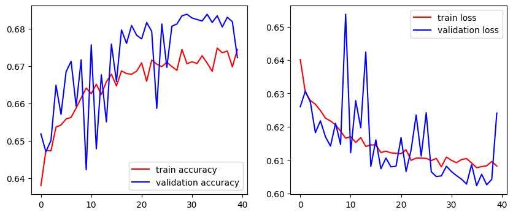

```python
plt.figure(figsize = (10,4))
plt.subplot(1,2,1)
plt.plot(resnet_model_history.history["accuracy"], label = "train accuracy", color = "red")
plt.plot(resnet_model_history.history["val_accuracy"], label = "validation accuracy", color = "blue")
plt.legend()

plt.subplot(1,2,2)
plt.plot(resnet_model_history.history["loss"], label = "train loss", color = "red")
plt.plot(resnet_model_history.history["val_loss"], label = "validation loss", color = "blue")

plt.legend()
plt.show()
```

```python
resnet_model_predictions = resnet_model.predict(x_test_images, verbose = 1,workers=-1)
```

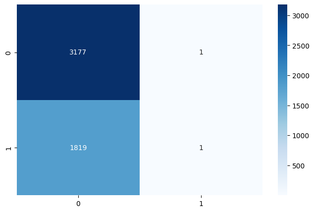

```python
plt.figure(figsize = (8,5))
sns.heatmap(confusion_matrix(y_test, resnet_model_predictions.round()), annot = True,fmt="d",cmap = "Blues")
plt.show()
```

```python
print(classification_report(y_test,resnet_model_predictions.round()))
```

```
              precision    recall  f1-score   support

           0       0.64      1.00      0.78      3178
           1       0.50      0.00      0.00      1820

    accuracy                           0.64      4998
   macro avg       0.57      0.50      0.39      4998
weighted avg       0.59      0.64      0.49      4998
```

## 5.7. MobileNetV2 Model

```python
# load MobileNetV2
base_model=MobileNetV2(weights='imagenet', include_top=False, input_shape=(128, 128, 3))
base_model.trainable = False

base_model.summary()
```

```
Model: "mobilenetv2_1.00_128"
__________________________________________________________________________________________________
Layer (type)                    Output Shape         Param #     Connected to
==================================================================================================
input_3 (InputLayer)            [(None, 128, 128, 3) 0
__________________________________________________________________________________________________
Conv1 (Conv2D)                  (None, 64, 64, 32)   864         input_3[0][0]
__________________________________________________________________________________________________
bn_Conv1 (BatchNormalization)   (None, 64, 64, 32)   128         Conv1[0][0]
__________________________________________________________________________________________________
Conv1_relu (ReLU)               (None, 64, 64, 32)   0           bn_Conv1[0][0]
__________________________________________________________________________________________________
expanded_conv_depthwise (Depthw (None, 64, 64, 32)   288         Conv1_relu[0][0]
__________________________________________________________________________________________________
expanded_conv_depthwise_BN (Bat (None, 64, 64, 32)   128         expanded_conv_depthwise[0][0]
__________________________________________________________________________________________________
expanded_conv_depthwise_relu (R (None, 64, 64, 32)   0           expanded_conv_depthwise_BN[0][0]
__________________________________________________________________________________________________
expanded_conv_project (Conv2D)  (None, 64, 64, 16)   512         expanded_conv_depthwise_relu[0][0
__________________________________________________________________________________________________
expanded_conv_project_BN (Batch (None, 64, 64, 16)   64          expanded_conv_project[0][0]
__________________________________________________________________________________________________
block_1_expand (Conv2D)         (None, 64, 64, 96)   1536        expanded_conv_project_BN[0][0]
__________________________________________________________________________________________________
block_1_expand_BN (BatchNormali (None, 64, 64, 96)   384         block_1_expand[0][0]
__________________________________________________________________________________________________
block_1_expand_relu (ReLU)      (None, 64, 64, 96)   0           block_1_expand_BN[0][0]
__________________________________________________________________________________________________
block_1_pad (ZeroPadding2D)     (None, 65, 65, 96)   0           block_1_expand_relu[0][0]
__________________________________________________________________________________________________
block_1_depthwise (DepthwiseCon (None, 32, 32, 96)   864         block_1_pad[0][0]
__________________________________________________________________________________________________
block_1_depthwise_BN (BatchNorm (None, 32, 32, 96)   384         block_1_depthwise[0][0]
__________________________________________________________________________________________________
block_1_depthwise_relu (ReLU)   (None, 32, 32, 96)   0           block_1_depthwise_BN[0][0]
__________________________________________________________________________________________________
block_1_project (Conv2D)        (None, 32, 32, 24)   2304        block_1_depthwise_relu[0][0]
__________________________________________________________________________________________________
block_1_project_BN (BatchNormal (None, 32, 32, 24)   96          block_1_project[0][0]
__________________________________________________________________________________________________
```

[output cut: 271 more lines]

```
__________________________________________________________________________________________________
block_16_project (Conv2D)       (None, 4, 4, 320)    307200      block_16_depthwise_relu[0][0]
__________________________________________________________________________________________________
block_16_project_BN (BatchNorma (None, 4, 4, 320)    1280        block_16_project[0][0]
__________________________________________________________________________________________________
Conv_1 (Conv2D)                 (None, 4, 4, 1280)   409600      block_16_project_BN[0][0]
__________________________________________________________________________________________________
Conv_1_bn (BatchNormalization)  (None, 4, 4, 1280)   5120        Conv_1[0][0]
__________________________________________________________________________________________________
out_relu (ReLU)                 (None, 4, 4, 1280)   0           Conv_1_bn[0][0]
==================================================================================================
Total params: 2,257,984
Trainable params: 0
Non-trainable params: 2,257,984
__________________________________________________________________________________________________
```

```python
mobilenet_model=Sequential()
mobilenet_model.add(base_model)

top_model=Sequential()
top_model.add(Flatten())

top_model.add(Dense(64, activation='relu'))

top_model.add(Dense(1, activation='sigmoid'))

mobilenet_model.add(top_model)

mobilenet_model.compile(loss='binary_crossentropy',
              optimizer='adam',
              metrics=['accuracy'])

mobilenet_model.summary()
```

```
Model: "sequential_4"
_________________________________________________________________
Layer (type)                 Output Shape              Param #
=================================================================
mobilenetv2_1.00_128 (Functi (None, 4, 4, 1280)        2257984
_________________________________________________________________
sequential_5 (Sequential)    (None, 1)                 1310849
=================================================================
Total params: 3,568,833
Trainable params: 1,310,849
Non-trainable params: 2,257,984
_________________________________________________________________
```

```python
mobilenet_model_history = mobilenet_model.fit_generator(train_generator,
                                                      validation_data  = valid_generator,
                                                      epochs = 100,
                                                      steps_per_epoch=(len(train_generator)) ,
                                                      validation_steps=(len(valid_generator)),
                                                      callbacks=[earlystop])
```

## 5.8. MobileNetV2 Model Evaluation

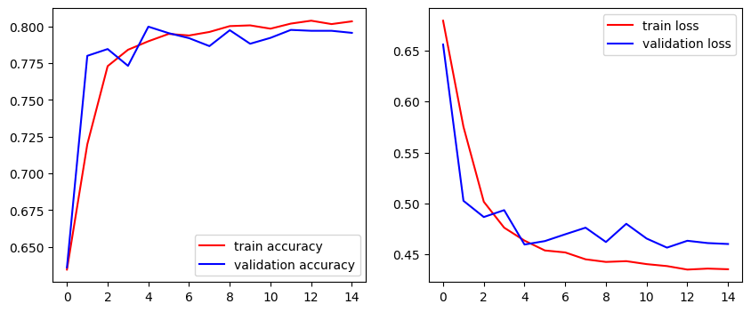

```python
plt.figure(figsize = (10,4))
plt.subplot(1,2,1)
plt.plot(mobilenet_model_history.history["accuracy"], label = "train accuracy", color = "red")
plt.plot(mobilenet_model_history.history["val_accuracy"], label = "validation accuracy", color = "blue")
plt.legend()

plt.subplot(1,2,2)
plt.plot(mobilenet_model_history.history["loss"], label = "train loss", color = "red")
plt.plot(mobilenet_model_history.history["val_loss"], label = "validation loss", color = "blue")

plt.legend()
plt.show()
```

```python
mobilenet_model_predictions = mobilenet_model.predict(x_test_images, verbose = 1,workers=-1)
```

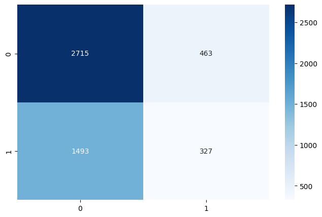

```python
plt.figure(figsize = (8,5))
sns.heatmap(confusion_matrix(y_test, mobilenet_model_predictions.round()), annot = True,fmt="d",cmap = "Blues")
plt.show()
```

```python
print(classification_report(y_test,mobilenet_model_predictions.round()))
```

```
              precision    recall  f1-score   support

           0       0.65      0.85      0.74      3178
           1       0.41      0.18      0.25      1820

    accuracy                           0.61      4998
   macro avg       0.53      0.52      0.49      4998
weighted avg       0.56      0.61      0.56      4998
```

# 6. Fine-tuning the Models

## 6.1. VGG16 Tuning

```python
base_model = vgg_model.layers[0]
base_model.trainable = True
print("Number of layers in the base model: ", len(base_model.layers))
```

```
Number of layers in the base model:  19
```

```python
# Fine-tune from this layer onwards
fine_tune_at = 10

for layer in base_model.layers[:fine_tune_at]:
    layer.trainable = False

ADAM_opt = Adam(learning_rate=0.0001)

vgg_model.compile(loss='binary_crossentropy',
              optimizer= ADAM_opt,
              metrics=['accuracy'])
```

```python
vgg_model_history_2 = vgg_model.fit_generator(train_generator,
                                                      validation_data  = valid_generator,
                                                      epochs = 100,
                                                      initial_epoch=vgg_model_history.epoch[-1],
                                                      steps_per_epoch=(len(train_generator)) ,
                                                      validation_steps=(len(valid_generator)),
                                                      callbacks=[earlystop])
```

## 6.2. VGG16 Model Evaluation After Tuning

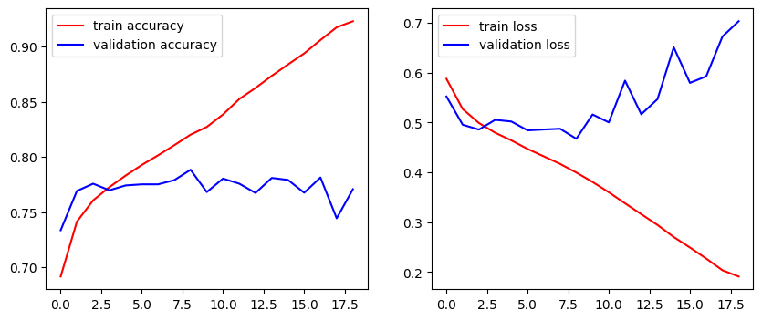

```python
plt.figure(figsize = (10,4))
plt.subplot(1,2,1)
plt.plot(vgg_model_history_2.history["accuracy"], label = "train accuracy", color = "red")
plt.plot(vgg_model_history_2.history["val_accuracy"], label = "validation accuracy", color = "blue")
plt.legend()

plt.subplot(1,2,2)
plt.plot(vgg_model_history_2.history["loss"], label = "train loss", color = "red")
plt.plot(vgg_model_history_2.history["val_loss"], label = "validation loss", color = "blue")

plt.legend()
plt.show()
```

```python
vgg_model_predictions = vgg_model.predict(x_test_images, verbose = 1,workers=-1)
```

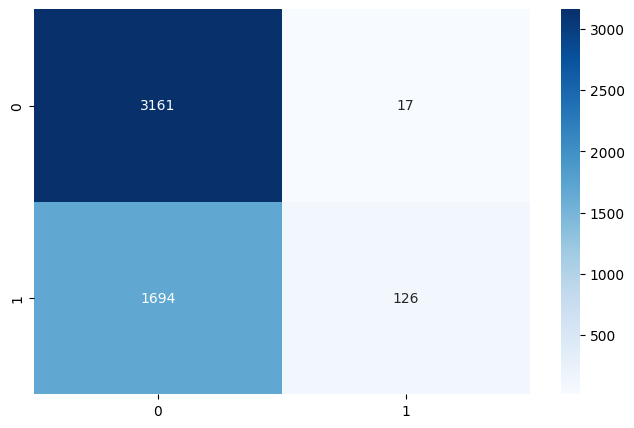

```python
plt.figure(figsize = (8,5))
sns.heatmap(confusion_matrix(y_test, vgg_model_predictions.round()), annot = True,fmt="d",cmap = "Blues")
plt.show()
```

```python
print(classification_report(y_test,vgg_model_predictions.round()))
```

```
              precision    recall  f1-score   support

           0       0.65      0.99      0.79      3178
           1       0.88      0.07      0.13      1820

    accuracy                           0.66      4998
   macro avg       0.77      0.53      0.46      4998
weighted avg       0.73      0.66      0.55      4998
```

```python
vgg_model.save('vgg_model_V3.h5')
```

## 6.3. RasNet50 Tuning

```python
base_model = resnet_model.layers[0]
base_model.trainable = True
print("Number of layers in the base model: ", len(base_model.layers))
```

```
Number of layers in the base model:  175
```

```python
# Fine-tune from this layer onwards
fine_tune_at = 135

for layer in base_model.layers[:fine_tune_at]:
    layer.trainable = False

ADAM_opt = Adam(learning_rate=0.0001)

resnet_model.compile(loss='binary_crossentropy',
              optimizer= ADAM_opt,
              metrics=['accuracy'])
```

```python
resnet_model_history_2 = resnet_model.fit_generator(train_generator,
                                                      validation_data  = valid_generator,
                                                      epochs = 100,
                                                      initial_epoch=resnet_model_history.epoch[-1],
                                                      steps_per_epoch=(len(train_generator)) ,
                                                      validation_steps=(len(valid_generator)),
                                                      callbacks=[earlystop])
```

## 6.4. RasNet50 Model Evaluation After Tuning

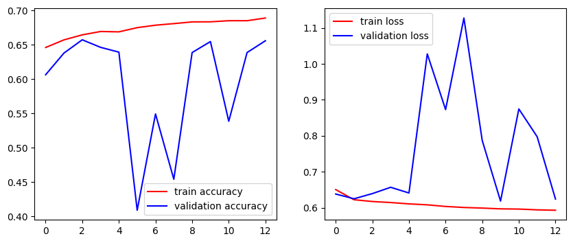

```python
plt.figure(figsize = (10,4))
plt.subplot(1,2,1)
plt.plot(resnet_model_history_2.history["accuracy"], label = "train accuracy", color = "red")
plt.plot(resnet_model_history_2.history["val_accuracy"], label = "validation accuracy", color = "blue")
plt.legend()

plt.subplot(1,2,2)
plt.plot(resnet_model_history_2.history["loss"], label = "train loss", color = "red")
plt.plot(resnet_model_history_2.history["val_loss"], label = "validation loss", color = "blue")

plt.legend()
plt.show()
```

```python
resnet_model_predictions = resnet_model.predict(x_test_images, verbose = 1,workers=-1)
```

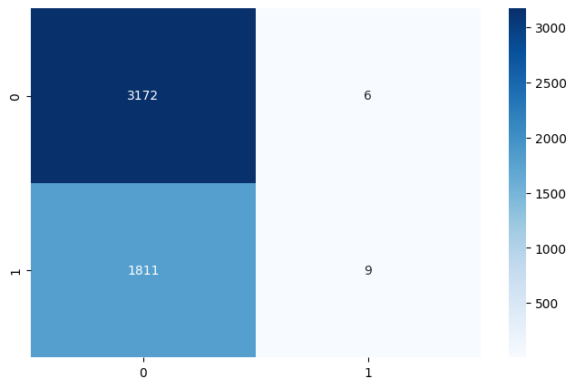

```python
plt.figure(figsize = (8,5))
sns.heatmap(confusion_matrix(y_test, resnet_model_predictions.round()), annot = True,fmt="d",cmap = "Blues")
plt.show()
```

```python
print(classification_report(y_test,resnet_model_predictions.round()))
```

```
              precision    recall  f1-score   support

           0       0.64      1.00      0.78      3178
           1       0.60      0.00      0.01      1820

    accuracy                           0.64      4998
   macro avg       0.62      0.50      0.39      4998
weighted avg       0.62      0.64      0.50      4998
```

```python
resnet_model.save('resnet_model_V3.h5')
```

## 6.5. MobileNetV2 Tuning

```python
base_model = mobilenet_model.layers[0]
base_model.trainable = True
print("Number of layers in the base model: ", len(base_model.layers))
```

```
Number of layers in the base model:  154
```

```python
# Fine-tune from this layer onwards
fine_tune_at = 120

for layer in base_model.layers[:fine_tune_at]:
    layer.trainable = False

ADAM_opt = Adam(learning_rate=0.0001)

mobilenet_model.compile(loss='binary_crossentropy',
              optimizer= ADAM_opt,
              metrics=['accuracy'])
```

```python
mobilenet_model_history_2 = mobilenet_model.fit_generator(train_generator,
                                                          validation_data  = valid_generator,
                                                          epochs = 100,
                                                          initial_epoch=mobilenet_model_history.epoch[-1],
                                                          steps_per_epoch=(len(train_generator)) ,
                                                          validation_steps=(len(valid_generator)),
                                                          callbacks=[earlystop])
```

## 6.6. MobileNetV2 Model Evaluation After Tuning

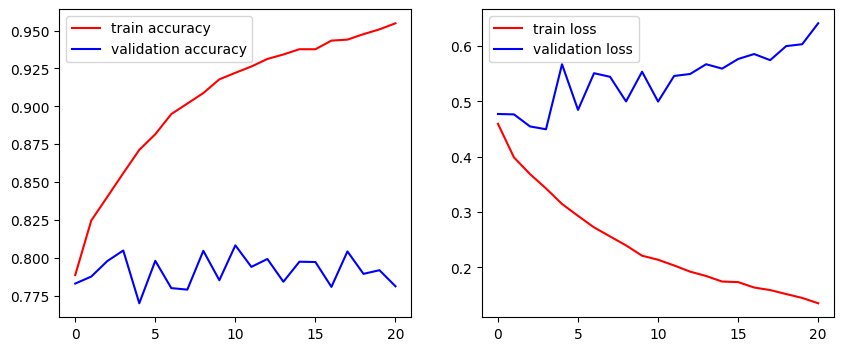

```python
plt.figure(figsize = (10,4))
plt.subplot(1,2,1)
plt.plot(mobilenet_model_history_2.history["accuracy"], label = "train accuracy", color = "red")
plt.plot(mobilenet_model_history_2.history["val_accuracy"], label = "validation accuracy", color = "blue")
plt.legend()

plt.subplot(1,2,2)
plt.plot(mobilenet_model_history_2.history["loss"], label = "train loss", color = "red")
plt.plot(mobilenet_model_history_2.history["val_loss"], label = "validation loss", color = "blue")

plt.legend()
plt.show()
```

```python
mobilenet_model_predictions = mobilenet_model.predict(x_test_images, verbose = 1,workers=-1)
```

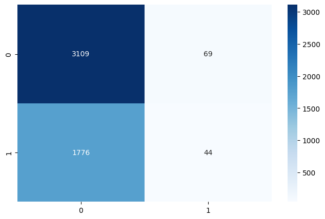

```python
plt.figure(figsize = (8,5))
sns.heatmap(confusion_matrix(y_test, mobilenet_model_predictions.round()), annot = True,fmt="d",cmap = "Blues")
plt.show()
```

```python
print(classification_report(y_test,mobilenet_model_predictions.round()))
```

```
              precision    recall  f1-score   support

           0       0.64      0.98      0.77      3178
           1       0.39      0.02      0.05      1820

    accuracy                           0.63      4998
   macro avg       0.51      0.50      0.41      4998
weighted avg       0.55      0.63      0.51      4998
```

```python
mobilenet_model.save('mobilenet_model_V3.h5')
```